# Progress of Covid-19 Vaccinations Worldwide

### Group: Group 1

### Team: Avinash Kumar, Vamsi Krishna, Vishwas Narayan

### Project: Digital Tools for Strategic Planning (DOORSTEP)

Import Statements for data analysis using pandas, data manipulation using numpy and plotting the visualizations such as choropleth map, line plots, horizontal barplots using plotly, matplotlib and seaborn.

```python
import pandas as pd
import numpy as np
import seaborn as sns
sns.set_theme(style="darkgrid")
import matplotlib.pyplot as plt
from pandas.plotting import radviz
import plotly.express as plotlybar
import plotly.express as px
import plotly.graph_objects as go
from plotly.subplots import make_subplots
from plotly.offline import download_plotlyjs, init_notebook_mode, plot, iplot
init_notebook_mode(connected=True)
import bar_chart_race as bcr
import warnings
warnings.filterwarnings('ignore')

#Imports for plotting
import matplotlib.pyplot as plt
from mpl_toolkits.mplot3d import Axes3D
import matplotlib as mpl
import seaborn as sns
from matplotlib.colors import ListedColormap
%matplotlib inline

#Import for mixed data
from prince import FAMD
from sklearn.datasets import make_blobs
from sklearn.cluster import KMeans
from kmodes.kprototypes import KPrototypes
from sklearn.preprocessing import StandardScaler
random_state = 1234
pd.options.plotting.backend = "plotly"
```

#### Reading the Dataset on COVID-19 (coronavirus) vaccinations

##### country_vaccinations_df:</br>

Dataframe Names: cv_df, country_vaccinations_df</br>

Country-by-country data on global COVID-19 vaccinations.</br> This dataset includes international aggregates (World, continents, European Union…). They can be identified by their iso_code. This dataset consists of the following columns:</br>

- country: name of the country (or region within a country).
- iso_code: ISO 3166-1 alpha-3 – three-letter country codes.
- date: date of the observation.
- total_vaccinations: total number of doses administered and so on.

##### country_vaccinations_by_manufacturer_df:</br>

Dataframe Names: cvm_df, country_vaccinations_by_manufacturer_df</br>

This dataset includes European and American locations. They can be identified by their location.</br>

- location: name of the country (or region within a country).
- date: date of the observation.
- vaccine: list of vaccines administered in the location.
- total_vaccinations: total number of doses administered.

```python
country_vaccinations_df=pd.read_csv('2021-05-19_country_vaccinations.csv')
country_vaccinations_by_manufacturer_df=pd.read_csv('2021-05-19_country_vaccinations_by_manufacturer.csv')
cv_df=country_vaccinations_df
cvm_df=country_vaccinations_by_manufacturer_df
```

```python
country_vaccinations_df.info()
```

```
<class 'pandas.core.frame.DataFrame'>
RangeIndex: 17607 entries, 0 to 17606
Data columns (total 15 columns):
 #   Column                               Non-Null Count  Dtype
---  ------                               --------------  -----
 0   country                              17607 non-null  object
 1   iso_code                             17607 non-null  object
 2   date                                 17607 non-null  object
 3   total_vaccinations                   10251 non-null  float64
 4   people_vaccinated                    9526 non-null   float64
 5   people_fully_vaccinated              7185 non-null   float64
 6   daily_vaccinations_raw               8568 non-null   float64
 7   daily_vaccinations                   17391 non-null  float64
 8   total_vaccinations_per_hundred       10251 non-null  float64
 9   people_vaccinated_per_hundred        9526 non-null   float64
 10  people_fully_vaccinated_per_hundred  7185 non-null   float64
 11  daily_vaccinations_per_million       17391 non-null  float64
 12  vaccines                             17607 non-null  object
 13  source_name                          17607 non-null  object
 14  source_website                       17607 non-null  object
dtypes: float64(9), object(6)
memory usage: 2.0+ MB
```

```python
country_vaccinations_by_manufacturer_df.info()
```

```
<class 'pandas.core.frame.DataFrame'>
RangeIndex: 3808 entries, 0 to 3807
Data columns (total 4 columns):
 #   Column              Non-Null Count  Dtype
---  ------              --------------  -----
 0   location            3808 non-null   object
 1   date                3808 non-null   object
 2   vaccine             3808 non-null   object
 3   total_vaccinations  3808 non-null   int64
dtypes: int64(1), object(3)
memory usage: 119.1+ KB
```

#### Changing the 'date' column into a proper datetime format.

```python
cv_df['date']=pd.to_datetime(cv_df['date'],format='%Y-%m-%d')
cvm_df['date']=pd.to_datetime(cvm_df['date'],format='%Y-%m-%d')
```

```python
cv_df
```

|  | country | iso_code | date | total_vaccinations | people_vaccinated | people_fully_vaccinated | daily_vaccinations_raw | daily_vaccinations | total_vaccinations_per_hundred | people_vaccinated_per_hundred | people_fully_vaccinated_per_hundred | daily_vaccinations_per_million | vaccines | source_name | source_website |
| --- | --- | --- | --- | --- | --- | --- | --- | --- | --- | --- | --- | --- | --- | --- | --- |
| 0 | Afghanistan | AFG | 2021-02-22 | 0.0 | 0.0 | NaN | NaN | NaN | 0.00 | 0.00 | NaN | NaN | Oxford/AstraZeneca, Pfizer/BioNTech, Sinopharm... | World Health Organization | https://covid19.who.int/ |
| 1 | Afghanistan | AFG | 2021-02-23 | NaN | NaN | NaN | NaN | 1367.0 | NaN | NaN | NaN | 35.0 | Oxford/AstraZeneca, Pfizer/BioNTech, Sinopharm... | World Health Organization | https://covid19.who.int/ |
| 2 | Afghanistan | AFG | 2021-02-24 | NaN | NaN | NaN | NaN | 1367.0 | NaN | NaN | NaN | 35.0 | Oxford/AstraZeneca, Pfizer/BioNTech, Sinopharm... | World Health Organization | https://covid19.who.int/ |
| 3 | Afghanistan | AFG | 2021-02-25 | NaN | NaN | NaN | NaN | 1367.0 | NaN | NaN | NaN | 35.0 | Oxford/AstraZeneca, Pfizer/BioNTech, Sinopharm... | World Health Organization | https://covid19.who.int/ |
| 4 | Afghanistan | AFG | 2021-02-26 | NaN | NaN | NaN | NaN | 1367.0 | NaN | NaN | NaN | 35.0 | Oxford/AstraZeneca, Pfizer/BioNTech, Sinopharm... | World Health Organization | https://covid19.who.int/ |
| ... | ... | ... | ... | ... | ... | ... | ... | ... | ... | ... | ... | ... | ... | ... | ... |
| 17602 | Zimbabwe | ZWE | 2021-05-08 | 657838.0 | 509274.0 | 148564.0 | 17076.0 | 19648.0 | 4.43 | 3.43 | 1.00 | 1322.0 | Sinopharm/Beijing | Ministry of Health | https://twitter.com/MoHCCZim/status/1392575941... |
| 17603 | Zimbabwe | ZWE | 2021-05-09 | 684243.0 | 526066.0 | 158177.0 | 26405.0 | 22863.0 | 4.60 | 3.54 | 1.06 | 1538.0 | Sinopharm/Beijing | Ministry of Health | https://twitter.com/MoHCCZim/status/1392575941... |
| 17604 | Zimbabwe | ZWE | 2021-05-10 | 690653.0 | 529360.0 | 161293.0 | 6410.0 | 21877.0 | 4.65 | 3.56 | 1.09 | 1472.0 | Sinopharm/Beijing | Ministry of Health | https://twitter.com/MoHCCZim/status/1392575941... |
| 17605 | Zimbabwe | ZWE | 2021-05-11 | 709772.0 | 539526.0 | 170246.0 | 19119.0 | 21428.0 | 4.78 | 3.63 | 1.15 | 1442.0 | Sinopharm/Beijing | Ministry of Health | https://twitter.com/MoHCCZim/status/1392575941... |
| 17606 | Zimbabwe | ZWE | 2021-05-12 | 730365.0 | 549797.0 | 180568.0 | 20593.0 | 22019.0 | 4.91 | 3.70 | 1.21 | 1481.0 | Sinopharm/Beijing | Ministry of Health | https://twitter.com/MoHCCZim/status/1392575941... |

17607 rows × 15 columns

```python
cvm_df
```

|  | location | date | vaccine | total_vaccinations |
| --- | --- | --- | --- | --- |
| 0 | Chile | 2020-12-24 | Pfizer/BioNTech | 420 |
| 1 | Chile | 2020-12-25 | Pfizer/BioNTech | 5198 |
| 2 | Chile | 2020-12-26 | Pfizer/BioNTech | 8338 |
| 3 | Chile | 2020-12-27 | Pfizer/BioNTech | 8649 |
| 4 | Chile | 2020-12-28 | Pfizer/BioNTech | 8649 |
| ... | ... | ... | ... | ... |
| 3803 | United States | 2021-05-12 | Moderna | 113582961 |
| 3804 | United States | 2021-05-12 | Pfizer/BioNTech | 141636737 |
| 3805 | United States | 2021-05-13 | Johnson&Johnson | 9352742 |
| 3806 | United States | 2021-05-13 | Moderna | 114354242 |
| 3807 | United States | 2021-05-13 | Pfizer/BioNTech | 142692755 |

3808 rows × 4 columns

#### cv_df_grp dataframe groups based on each country with it's maximum value in each column.

```python
cv_df_grp = cv_df.groupby('country').max().reset_index()
cv_df_grp
```

|  | country | iso_code | date | total_vaccinations | people_vaccinated | people_fully_vaccinated | daily_vaccinations_raw | daily_vaccinations | total_vaccinations_per_hundred | people_vaccinated_per_hundred | people_fully_vaccinated_per_hundred | daily_vaccinations_per_million | vaccines | source_name | source_website |
| --- | --- | --- | --- | --- | --- | --- | --- | --- | --- | --- | --- | --- | --- | --- | --- |
| 0 | Afghanistan | AFG | 2021-05-11 | 504502.0 | 448878.0 | 55624.0 | NaN | 13921.0 | 1.30 | 1.15 | 0.14 | 358.0 | Oxford/AstraZeneca, Pfizer/BioNTech, Sinopharm... | World Health Organization | https://covid19.who.int/ |
| 1 | Albania | ALB | 2021-05-12 | 632676.0 | 444755.0 | 187921.0 | 23655.0 | 17565.0 | 21.98 | 15.45 | 6.53 | 6104.0 | Oxford/AstraZeneca, Pfizer/BioNTech, Sinovac, ... | Ministry of Health | https://shendetesia.gov.al/vaksinimi-anticovid... |
| 2 | Algeria | DZA | 2021-02-19 | 75000.0 | NaN | NaN | 30.0 | 3748.0 | 0.17 | NaN | NaN | 85.0 | Sputnik V | Ministry of Health | https://www.echoroukonline.com/%d9%84%d9%82%d8... |
| 3 | Andorra | AND | 2021-05-10 | 31633.0 | 26931.0 | 4702.0 | 2829.0 | 1182.0 | 40.94 | 34.86 | 6.09 | 15298.0 | Oxford/AstraZeneca, Pfizer/BioNTech | Government of Andorra | https://www.govern.ad/covid19_newsletter/ |
| 4 | Angola | AGO | 2021-05-12 | 626572.0 | 586377.0 | 40195.0 | NaN | 18751.0 | 1.91 | 1.78 | 0.12 | 571.0 | Oxford/AstraZeneca | World Health Organization | https://covid19.who.int/ |
| ... | ... | ... | ... | ... | ... | ... | ... | ... | ... | ... | ... | ... | ... | ... | ... |
| 206 | Wales | OWID_WLS | 2021-05-12 | 2853576.0 | 1975820.0 | 877756.0 | 40211.0 | 33151.0 | 90.51 | 62.67 | 27.84 | 10515.0 | Moderna, Oxford/AstraZeneca, Pfizer/BioNTech | Government of the United Kingdom | https://coronavirus.data.gov.uk/details/health... |
| 207 | Wallis and Futuna | WLF | 2021-05-11 | 5774.0 | 4286.0 | 1488.0 | NaN | 272.0 | 51.34 | 38.11 | 13.23 | 24186.0 | Oxford/AstraZeneca | SPC Public Health Division | https://stats.pacificdata.org/vis?tm=covid&pg=... |
| 208 | Yemen | YEM | 2021-05-09 | 18555.0 | 18555.0 | NaN | NaN | NaN | 0.06 | 0.06 | NaN | NaN | Oxford/AstraZeneca | World Health Organization | https://covid19.who.int/ |
| 209 | Zambia | ZMB | 2021-05-12 | 90916.0 | 90916.0 | NaN | 7198.0 | 5680.0 | 0.49 | 0.49 | NaN | 309.0 | Oxford/AstraZeneca | Government of Zambia | https://www.facebook.com/mohzambia/photos/a.77... |
| 210 | Zimbabwe | ZWE | 2021-05-12 | 730365.0 | 549797.0 | 180568.0 | 33407.0 | 22863.0 | 4.91 | 3.70 | 1.21 | 1538.0 | Sinopharm/Beijing | Ministry of Health | https://twitter.com/MoHCCZim/status/1392575941... |

211 rows × 15 columns

# Which countries have the best vaccination progress?

#### Total COVID-19 Vaccinations Country-by-Country</br>

The Choropleth Map below shows the countries with total vaccinations. The countries that are purple are less vaccinated compared to the countries which are yellow/ brown. We find that China, India and United States some of the countries that has made the best vaccination progress.

```python
figure = px.choropleth(cv_df_grp,
                       locations='iso_code',
                       color='total_vaccinations',
                       hover_name='country',
                       color_continuous_scale='portland',
                       title='Total COVID-19 Vaccinations',
                       featureidkey="properties.country",
#                        animation_frame='dt_str'
                      )

figure.update_layout(
    title_text = 'Total COVID-19 Vaccinations',
    title_x = 0.5,
    geo=dict(
        showframe = False,
        showcoastlines = False,
        projection_type = 'equirectangular'
    ))

figure.show()
```

[interactive chart not shown]

#### People Vaccinated by COVID-19 Vaccine Country-by-Country</br>

The Choropleth Map below shows the countries that the total number of people who received at least one vaccine dose. If a person receives the first dose of a 2-dose vaccine, this metric goes up by 1. The countries that are dark blue/sky blue are less vaccinated compared to the countries which are dark red/brown. We find that India and United States some of the countries that has made the best vaccination progress.

The dataframe vac_df is used to store the group information based on the 'date', 'iso_code' and 'country' data to create a timeline_df dataframe to visualize the from 1st Jan to 13th May 2021 of the people who are vaccinated in this date range.

```python
vac_df = cv_df.groupby(['date','iso_code','country']).sum().reset_index().sort_values('date', ascending=True).dropna()
mask = (vac_df['date'] > '2021-01-01') & (vac_df['date'] <= '2021-12-31')
vac_df['dt_str'] = vac_df['date'].apply(lambda x: x.strftime("%m/%d/%Y"))
timeline_df = vac_df.loc[mask]
timeline_df = timeline_df[timeline_df['daily_vaccinations']>0]
timeline_df
```

|  | date | iso_code | country | total_vaccinations | people_vaccinated | people_fully_vaccinated | daily_vaccinations_raw | daily_vaccinations | total_vaccinations_per_hundred | people_vaccinated_per_hundred | people_fully_vaccinated_per_hundred | daily_vaccinations_per_million | dt_str |
| --- | --- | --- | --- | --- | --- | --- | --- | --- | --- | --- | --- | --- | --- |
| 343 | 2021-01-02 | MCO | Monaco | 0.0 | 0.0 | 0.0 | 0.0 | 126.0 | 0.00 | 0.00 | 0.00 | 3211.0 | 01/02/2021 |
| 342 | 2021-01-02 | LVA | Latvia | 0.0 | 0.0 | 0.0 | 0.0 | 417.0 | 0.00 | 0.00 | 0.00 | 221.0 | 01/02/2021 |
| 341 | 2021-01-02 | LUX | Luxembourg | 0.0 | 0.0 | 0.0 | 0.0 | 62.0 | 0.00 | 0.00 | 0.00 | 99.0 | 01/02/2021 |
| 337 | 2021-01-02 | ITA | Italy | 89412.0 | 89412.0 | 0.0 | 38526.0 | 13706.0 | 0.15 | 0.15 | 0.00 | 227.0 | 01/02/2021 |
| 338 | 2021-01-02 | KWT | Kuwait | 0.0 | 0.0 | 0.0 | 0.0 | 1121.0 | 0.00 | 0.00 | 0.00 | 262.0 | 01/02/2021 |
| ... | ... | ... | ... | ... | ... | ... | ... | ... | ... | ... | ... | ... | ... |
| 17569 | 2021-05-13 | IDN | Indonesia | 22617205.0 | 13697256.0 | 8919949.0 | 0.0 | 178493.0 | 8.27 | 5.01 | 3.26 | 653.0 | 05/13/2021 |
| 17570 | 2021-05-13 | IND | India | 178361846.0 | 139087590.0 | 39274256.0 | 2316269.0 | 2251178.0 | 12.92 | 10.08 | 2.85 | 1631.0 | 05/13/2021 |
| 17571 | 2021-05-13 | ISR | Israel | 10525163.0 | 5430921.0 | 5094242.0 | 5165.0 | 5010.0 | 121.60 | 62.75 | 58.86 | 579.0 | 05/13/2021 |
| 17557 | 2021-05-13 | CZE | Czechia | 3991985.0 | 2919036.0 | 1094296.0 | 85621.0 | 66986.0 | 37.28 | 27.26 | 10.22 | 6255.0 | 05/13/2021 |
| 17606 | 2021-05-13 | ZAF | South Africa | 455169.0 | 455169.0 | 455169.0 | 24439.0 | 11648.0 | 0.77 | 0.77 | 0.77 | 196.0 | 05/13/2021 |

17099 rows × 13 columns

```python
figure = px.choropleth(timeline_df,
                       locations='iso_code',
                       color='people_vaccinated',
                       hover_name='country',
                       color_continuous_scale=px.colors.sequential.Turbo,
                       title='People Vaccinated by COVID-19 Vaccine from 1st Jan to 13th May 2021',
                       animation_frame='dt_str'
                      )

figure.update_layout(
    title_text = 'People Vaccinated by COVID-19 Vaccine from 1st Jan to 13th May 2021',
    title_x = 0.5,
    geo=dict(
        showframe = False,
        showcoastlines = False,
        projection_type = 'equirectangular'
    ))

figure.show()
```

[interactive chart not shown]

#### People Fully vaccinated by COVID-19 Vaccine Country-by-Country</br>

The Choropleth Map below shows the countries with total number of people who received all doses prescribed by the vaccination protocol. If a person receives the first dose of a 2-dose vaccine, this metric stays the same. If they receive the second dose, the metric goes up by 1. The countries like "India" is moderately vaccinated and "United States" made the best progress in vaccination. The white regions represent countries that does not have sufficient data.

```python
figure = px.choropleth(cv_df_grp,
                       locations='iso_code',
                       color='people_fully_vaccinated',
                       hover_name='country',
                       color_continuous_scale=px.colors.sequential.Turbo,
                       title='People fully vaccinated by COVID-19 Vaccines')

figure.update_layout(
    title_text = 'People Fully Vaccinated by COVID-19 Vaccine',
    title_x = 0.5,
    geo=dict(
        showframe = False,
        showcoastlines = False,
        projection_type = 'equirectangular'
    ))

figure.show()
```

[interactive chart not shown]

#### Horizontal Barplot: Top 10 Countries with highest total vaccinations

The horizontal barplot shows the top 10 countries that made best progress in terms of total number of vaccinations. The countries are grouped based on the maximum cumulative value of each column value. The countries such as 'China', 'United States', 'India','UK' are the top countries that made the best progress.

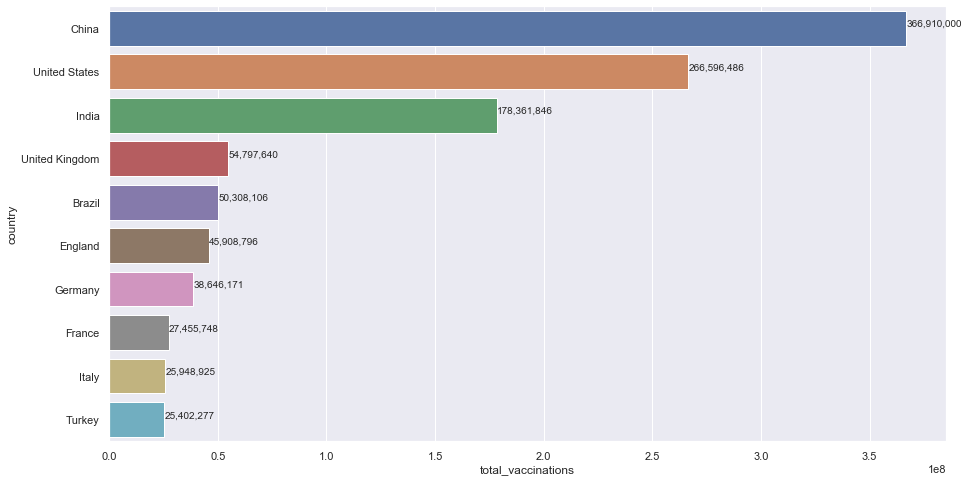

```python
top_10 = cv_df_grp.sort_values(by=['total_vaccinations'],ascending=False).head(10)
plt.figure(figsize=(15,8))
x=top_10['total_vaccinations']
y=top_10['country']
plot = sns.barplot(x,y)
for i,(value,name) in enumerate(zip(x,y)):
    plot.text(value,i-0.05,f'{value:,.0f}',size=10)
plt.show()
```

#### Horizontal Barplot: Top 10 Countries with highest number of people vaccinated with atleast 1 dose

The horizontal barplot shows the top 10 countries that made best progress in terms of the total number of people who received at least one vaccine dose. The countries are grouped based on the maximum cumulative value of each column value. The countries such as 'United States', 'India','UK' are the top countries that made the best progress. There's insufficient data for 'China' but it's among the top countries in terms of vaccinations.

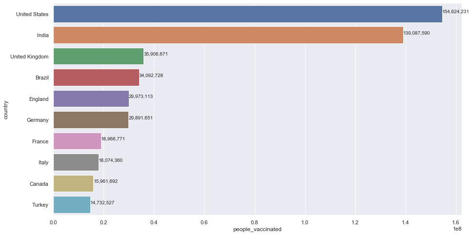

```python
top_10 = cv_df_grp.sort_values(by=['people_vaccinated'],ascending=False).head(10)
plt.figure(figsize=(15,8))
x=top_10['people_vaccinated']
y=top_10['country']
plot = sns.barplot(x,y)
for i,(value,name) in enumerate(zip(x,y)):
    plot.text(value,i-0.05,f'{value:,.0f}',size=10)
plt.show()
```

#### Horizontal Barplot: Top 10 Countries with highest number of people fully vaccinated

The horizontal barplot shows the top 10 countries that made best progress in terms of the total number of people who are fully vaccinated. The countries are grouped based on the maximum cumulative value of each column value. The countries such as 'United States', 'India','UK' are the top countries that made the best progress. There's insufficient data for 'China' but it's among the top countries in terms of vaccinations.

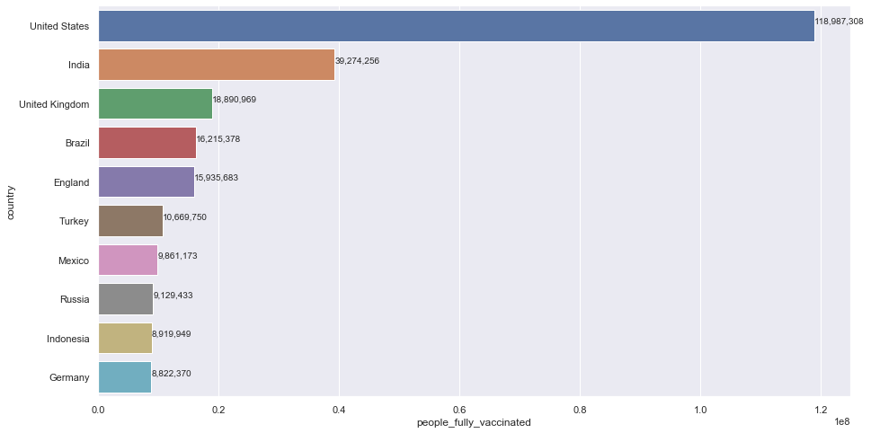

```python
top_10 = cv_df_grp.sort_values(by=['people_fully_vaccinated'],ascending=False).head(10)
plt.figure(figsize=(15,8))
x=top_10['people_fully_vaccinated']
y=top_10['country']
plot = sns.barplot(x,y)
for i,(value,name) in enumerate(zip(x,y)):
    plot.text(value,i-0.05,f'{value:,.0f}',size=10)
plt.show()
```

#### Horizontal Barplot: Top 5 Countries with highest number of vaccinated with atleast 1 dose versus people fully vaccinated

The horizontal barplot shows the top 5 countries that made best progress in terms of the total number of people who received at least one vaccine dose versus the total number of people who are fully vaccinated. The countries such as 'United States', 'India','UK' are the top countries that made the best progress and this confirms the similar trend from the previous visualizations. However, we can also see that there is significant difference between 'United States' and 'India' in terms of dosage provided to its citizens.

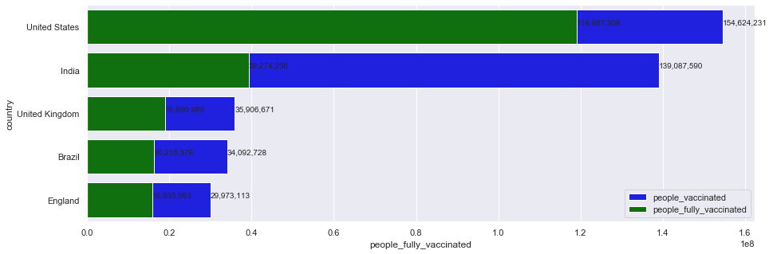

```python
top_5 = cv_df_grp.sort_values(by=['people_vaccinated'], ascending=False).head(5)

### Generate a Barplot
plt.figure(figsize=(15,5))
people_vaccinated = sns.barplot(top_5['people_vaccinated'], top_5['country'], color = 'blue', label='people_vaccinated')
people_fully_vaccinated = sns.barplot(top_5['people_fully_vaccinated'], top_5['country'], color = 'green', label='people_fully_vaccinated')
### Add Texts for Barplots
for i,(value,name) in enumerate(zip(top_5['people_fully_vaccinated'],top_5['country'])):
    people_vaccinated.text(value,i-0.05,f'{value:,.0f}',size=10)
for i,(value,name) in enumerate(zip(top_5['people_vaccinated'],top_5['country'])):
    people_fully_vaccinated.text(value,i-0.05,f'{value:,.0f}',size=10)
plt.legend(loc=4)
plt.show()
```

#### Relational line plot of top 10 Countries with highest number of total vaccinations

The relational line plot shows the top 10 countries that made best progress in terms of total vaccinations(cumulative). The countries such as 'China','United States', 'India','UK' are the top countries that made the best progress. Overall, China has made the best progress in terms of total vaccinations.

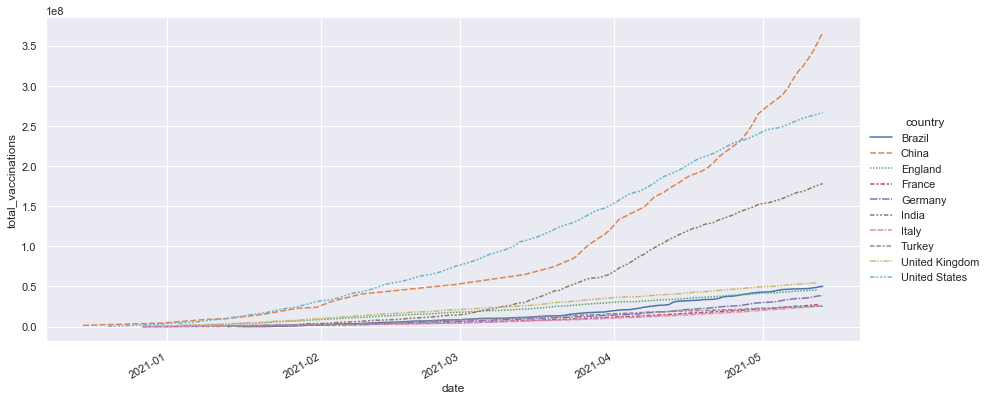

```python
top_10 = cv_df_grp.sort_values(by=['total_vaccinations'],ascending=False).head(10)
top_country_data = cv_df[cv_df['country'].isin(top_10['country'])]
sns.relplot(x="date", y="total_vaccinations", hue='country', style='country', kind="line", height=6,aspect=2, data=top_country_data).fig.autofmt_xdate()
```

#### Relational line plot of top 10 Countries with highest number of total vaccinations per hundred

The relational line plot shows the top 10 countries that made best progress in terms of total vaccinations per hundred(cumulative). The countries such as 'United States','UK' are the top countries that made the best progress.

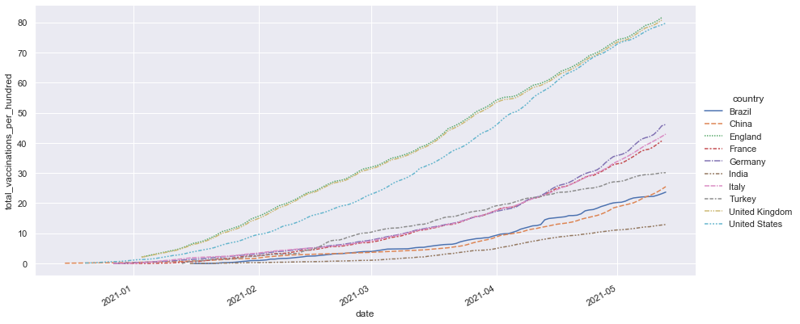

```python
top_10 = cv_df_grp.sort_values(by=['total_vaccinations'],ascending=False).head(10)
top_country_data = cv_df[cv_df['country'].isin(top_10['country'])]
sns.relplot(x="date", y="total_vaccinations_per_hundred", hue='country', style='country', kind="line", height=6,aspect=2, data=top_country_data).fig.autofmt_xdate()
```

#### Relational line plot of top 10 Countries with highest number of people vaccinated

The relational line plot shows the top 10 countries that made best progress in terms of total number of people who received at least one vaccine dose. The countries such as 'United States','India' and 'UK' are the top countries that made the best progress.

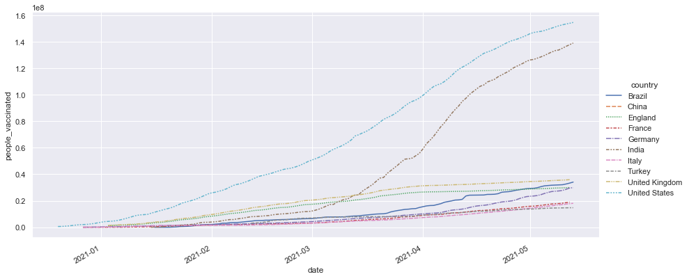

```python
top_10 = cv_df_grp.sort_values(by=['total_vaccinations'],ascending=False).head(10)
top_country_data = cv_df[cv_df['country'].isin(top_10['country'])]
sns.relplot(x="date", y="people_vaccinated", hue='country', style='country', kind="line", height=6,aspect=2, data=top_country_data).fig.autofmt_xdate()
```

#### Relational line plot of top 10 Countries with highest number of daily vaccinations

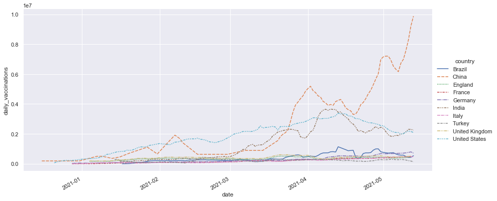

```python
top_10 = cv_df_grp.sort_values(by=['total_vaccinations'],ascending=False).head(10)
top_country_data = cv_df[cv_df['country'].isin(top_10['country'])]
sns.relplot(x="date", y="daily_vaccinations", hue='country', style='country', kind="line", height=6,aspect=2, data=top_country_data).fig.autofmt_xdate()
```

#### Relational line plot of top 10 Countries with highest number of daily vaccinations per million people

The relational line plot shows the top 10 countries that made best progress in terms of daily_vaccinations per 1,000,000 people in the total population of the country. Here, 'Germany','France','England' and 'United States' were consistent in providing daily vaccinations per million people

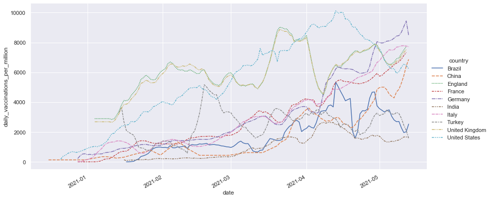

```python
top_10 = cv_df_grp.sort_values(by=['total_vaccinations'],ascending=False).head(10)
top_country_data = cv_df[cv_df['country'].isin(top_10['country'])]
top_country_pt = top_country_data.pivot_table(index=['country','date'],values=['daily_vaccinations_per_million'],aggfunc=np.sum).reset_index()
sns.relplot(x="date", y="daily_vaccinations_per_million", hue='country', style='country', kind="line", height=6,aspect=2, data=top_country_data).fig.autofmt_xdate()
```

# How are the vaccination progress and the number of positive cases, deaths etc. linked in the United States?

#### State-by-state data on United States COVID-19 vaccinations and COVID-19 positive cases and deaths.

The file 'us_states_vaccination.xlsx' consists of the COVID-19 vaccination information of the different states of United States. The US states data mainly consists of the total number of doses administered and the daily number of doses administered to its citizens.

#### Reading and Formatting the COVID-19 vaccine information of United States in the correct format for visualization

```python
us_vaccine_df = pd.read_excel('us_states_vaccination.xlsx')
us_vaccine_df['date']=pd.to_datetime(us_vaccine_df['date'],format='%Y-%m-%d')
us_vaccine_df.rename(columns={'location':'State'},inplace=True)
us_vaccine_df = us_vaccine_df.drop(columns=['Unnamed: 0'])
us_vaccine_df
```

|  | date | State | total_vaccinations | total_distributed | people_vaccinated | people_fully_vaccinated_per_hundred | total_vaccinations_per_hundred | people_fully_vaccinated | people_vaccinated_per_hundred | distributed_per_hundred | daily_vaccinations_raw | daily_vaccinations | daily_vaccinations_per_million | share_doses_used |
| --- | --- | --- | --- | --- | --- | --- | --- | --- | --- | --- | --- | --- | --- | --- |
| 0 | 2021-01-12 | Alabama | 78134.0 | 377025.0 | 70861.0 | 0.15 | 1.59 | 7270.0 | 1.45 | 7.69 | NaN | NaN | NaN | 0.207 |
| 1 | 2021-01-13 | Alabama | 84040.0 | 378975.0 | 74792.0 | 0.19 | 1.71 | 9245.0 | 1.53 | 7.73 | 5906.0 | 5906.0 | 1205.0 | 0.222 |
| 2 | 2021-01-14 | Alabama | 92300.0 | 435350.0 | 80480.0 | NaN | 1.88 | NaN | 1.64 | 8.88 | 8260.0 | 7083.0 | 1445.0 | 0.212 |
| 3 | 2021-01-15 | Alabama | 100567.0 | 444650.0 | 86956.0 | 0.28 | 2.05 | 13488.0 | 1.77 | 9.07 | 8267.0 | 7478.0 | 1525.0 | 0.226 |
| 4 | 2021-01-16 | Alabama | NaN | NaN | NaN | NaN | NaN | NaN | NaN | NaN | 7557.0 | 7498.0 | 1529.0 | NaN |
| ... | ... | ... | ... | ... | ... | ... | ... | ... | ... | ... | ... | ... | ... | ... |
| 7779 | 2021-05-26 | Wyoming | 390857.0 | 501965.0 | 211764.0 | 31.38 | 67.53 | 181605.0 | 36.59 | 86.73 | 132.0 | 1379.0 | 2383.0 | 0.779 |
| 7780 | 2021-05-27 | Wyoming | 390938.0 | 502365.0 | 211859.0 | 31.40 | 67.55 | 181712.0 | 36.61 | 86.80 | 81.0 | 940.0 | 1624.0 | 0.778 |
| 7781 | 2021-05-28 | Wyoming | 394278.0 | 502465.0 | 213605.0 | 31.69 | 68.12 | 183417.0 | 36.91 | 86.82 | 3340.0 | 1193.0 | 2061.0 | 0.785 |
| 7782 | 2021-05-29 | Wyoming | 395527.0 | 505565.0 | 214292.0 | 31.81 | 68.34 | 184128.0 | 37.03 | 87.35 | 1249.0 | 1074.0 | 1856.0 | 0.782 |
| 7783 | 2021-05-30 | Wyoming | 395615.0 | 505565.0 | 214360.0 | 31.82 | 68.36 | 184183.0 | 37.04 | 87.35 | 88.0 | 1070.0 | 1849.0 | 0.783 |

7784 rows × 14 columns

#### Reading and Formatting the United States COVID-19 data from previous tasks in the proper format for visualization

```python
us_postal_code_df=pd.read_excel('US postal code.xlsx')
us_states_df=pd.read_csv('2021-04-21_us_states_covid19_daily.csv')
us_states_df['date']=pd.to_datetime(us_states_df['date'],format='%Y%m%d')
us_states_df.rename(columns={'state':'Postal Code'},inplace=True)
us_states_df=us_states_df.merge(us_postal_code_df,on=['Postal Code'],how='left')
us_states_df.rename(columns={'State/District':'State'},inplace=True)
us_states_df
```

|  | date | Postal Code | positive | probableCases | negative | pending | totalTestResultsSource | totalTestResults | hospitalizedCurrently | hospitalizedCumulative | ... | deathIncrease | hospitalizedIncrease | hash | commercialScore | negativeRegularScore | negativeScore | positiveScore | score | grade | State |
| --- | --- | --- | --- | --- | --- | --- | --- | --- | --- | --- | --- | --- | --- | --- | --- | --- | --- | --- | --- | --- | --- |
| 0 | 2020-12-06 | TX | 1249323.0 | NaN | 10111653.0 | NaN | posNeg | 11360976.0 | 8681.0 | NaN | ... | 92 | 0 | 185c8e636d535c050ada41c45c885e4dc90d1caa | 0 | 0 | 0 | 0 | 0 | NaN | Texas |
| 1 | 2020-12-05 | TX | 1240750.0 | NaN | 10002003.0 | NaN | posNeg | 11242753.0 | 8916.0 | NaN | ... | 247 | 0 | 9227ed6579ae25ec126657f233d279d719a5c6f3 | 0 | 0 | 0 | 0 | 0 | NaN | Texas |
| 2 | 2020-12-04 | TX | 1228812.0 | NaN | 9882224.0 | NaN | posNeg | 11111036.0 | 9015.0 | NaN | ... | 255 | 0 | 2a6741684b0793da52834d6cd04d8499985af381 | 0 | 0 | 0 | 0 | 0 | NaN | Texas |
| 3 | 2020-12-03 | TX | 1215113.0 | NaN | 9802334.0 | NaN | posNeg | 11017447.0 | 9151.0 | NaN | ... | 244 | 0 | 809b1288e43efdb1f19e665c4c50fbc6d15dd0dc | 0 | 0 | 0 | 0 | 0 | NaN | Texas |
| 4 | 2020-12-02 | TX | 1200674.0 | NaN | 9731872.0 | NaN | posNeg | 10932546.0 | 9109.0 | NaN | ... | 207 | 0 | b5531c6a96f964b0c84c785b2e6d1a4b6cf1650d | 0 | 0 | 0 | 0 | 0 | NaN | Texas |
| ... | ... | ... | ... | ... | ... | ... | ... | ... | ... | ... | ... | ... | ... | ... | ... | ... | ... | ... | ... | ... | ... |
| 15628 | 2020-01-24 | WA | 0.0 | NaN | 0.0 | NaN | totalTestEncountersViral | 0.0 | NaN | NaN | ... | 0 | 0 | 82726df68eb97c98a4a6ee792349e547023147d5 | 0 | 0 | 0 | 0 | 0 | NaN | Washington |
| 15629 | 2020-01-23 | MA | NaN | NaN | NaN | NaN | totalTestsViral | 2.0 | NaN | NaN | ... | 0 | 0 | 76bc987d054b119a4e05a4a43742249c0b0568b6 | 0 | 0 | 0 | 0 | 0 | NaN | Massachusetts |
| 15630 | 2020-01-23 | WA | 0.0 | NaN | 0.0 | NaN | totalTestEncountersViral | 0.0 | NaN | NaN | ... | 0 | 0 | 1c2229c239ffad5e5fdd9d76c641dc9166caf6ba | 0 | 0 | 0 | 0 | 0 | NaN | Washington |
| 15631 | 2020-01-22 | MA | NaN | NaN | NaN | NaN | totalTestsViral | 1.0 | NaN | NaN | ... | 0 | 0 | 01f5dcd6631859503ef1b62d81d49e41d12fc1bd | 0 | 0 | 0 | 0 | 0 | NaN | Massachusetts |
| 15632 | 2020-01-22 | WA | 0.0 | NaN | 0.0 | NaN | totalTestEncountersViral | 0.0 | NaN | NaN | ... | 0 | 0 | 4502685e582e68071bfe8f7e1b307bc09c16728d | 0 | 0 | 0 | 0 | 0 | NaN | Washington |

15633 rows × 56 columns

#### Grouping of the COVID-19 vaccination and COVID-19 cases in the United States by aggregation with their respective 'States'

```python
us_vaccine_grp = us_vaccine_df.groupby('State').sum().reset_index()
us_states_grp = us_states_df.groupby('State').sum().reset_index()
```

The relational line plot shows the top 10 states that made best progress in terms of total vaccinations(cumulative). The states such as 'California','Texas', 'Florida' and 'New York' are the top states that made the best progress.

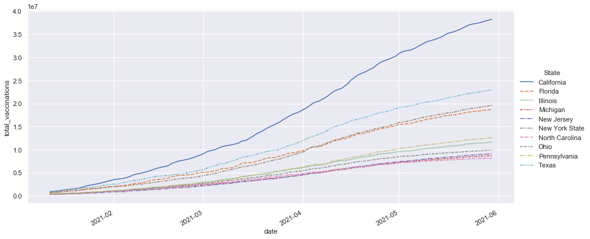

```python
top_10_us_vaccine_states = us_vaccine_grp.sort_values(by=['total_vaccinations'],ascending=False).head(10)
top_us_states_data = us_vaccine_df[us_vaccine_df['State'].isin(top_10_us_vaccine_states['State'])]
top_us_states_pt = top_us_states_data.pivot_table(index=['State','date'],values=['total_vaccinations'],aggfunc=np.sum).reset_index()
sns.relplot(x="date", y="total_vaccinations", hue='State', style='State', kind="line", height=6,aspect=2, data=top_us_states_data).fig.autofmt_xdate()
```

#### Horizontal Barplot: top 10 states with total vaccinations in the United States

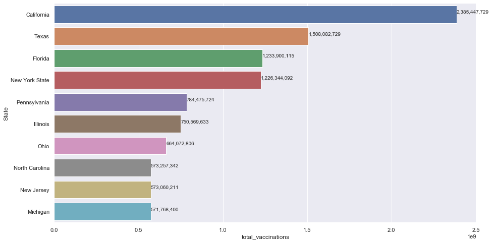

```python
top_10_us_vaccine = us_vaccine_grp.sort_values(by=['total_vaccinations'],ascending=False).head(10)
plt.figure(figsize=(15,8))
x=top_10_us_vaccine['total_vaccinations']
y=top_10_us_vaccine['State']
plot = sns.barplot(x,y)
for i,(value,name) in enumerate(zip(x,y)):
    plot.text(value,i-0.05,f'{value:,.0f}',size=10)
plt.show()
```

#### Relational line plot of top 10 States with highest number of positive cases

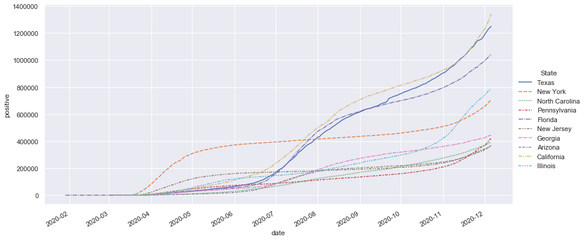

```python
top_10_us_states = us_states_grp.sort_values(by=['positive'],ascending=False).head(10)
top_us_states_data = us_states_df[us_states_df['State'].isin(top_10_us_states['State'])]
top_us_states_pt = top_us_states_data.pivot_table(index=['State','date'],values=['positive'],aggfunc=np.sum).reset_index()
sns.relplot(x="date", y="positive", hue='State', style='State', kind="line", height=6,aspect=2, data=top_us_states_data).fig.autofmt_xdate()
```

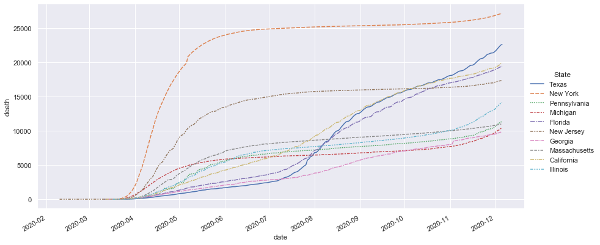

```python
top_10_us_states = us_states_grp.sort_values(by=['death'],ascending=False).head(10)
top_us_states_data = us_states_df[us_states_df['State'].isin(top_10_us_states['State'])]
top_us_states_pt = top_us_states_data.pivot_table(index=['State','date'],values=['death'],aggfunc=np.sum).reset_index()
sns.relplot(x="date", y="death", hue='State', style='State', kind="line", height=6,aspect=2, data=top_us_states_data).fig.autofmt_xdate()
```

# What are the main clusters among the countries and how can they be characterized?

```python
import pandas as pd
import numpy as np
from matplotlib import pyplot as plt
from sklearn.cluster import KMeans
from sklearn.metrics import silhouette_score
from sklearn.preprocessing import StandardScaler
%matplotlib inline
#import plotly.express as plotlybar
import plotly.express as px
import plotly.graph_objects as go
from plotnine import *

import bar_chart_race as bcr

from matplotlib.animation import FuncAnimation
%matplotlib notebook
```

```python
Country_vaccinations_data = pd.read_csv('2021-05-19_country_vaccinations.csv')
Vaccination_data_by_manufacturer = pd.read_csv('2021-05-19_country_vaccinations_by_manufacturer.csv')
```

# PreProcessing the Data for clustering

Here we are creating a new DataFrame object 'new_df' by grouping the data in 'Country_Vaccinations_data' by country.

To group the data based on country name and considering the features like "total_vaccinations','people_fully_vaccinated' and 'people_vaccinated',we are using the groupby and agggregation functions.

groupby('country') - groups the data based on country

agg.('column*name':'max* - find the maximum value of respective column for each country.

Since when grouping the index will be by default set to the country name ,we are using the reset_index() function to reset the index to row numbers.

```python
#columns = ['iso_code','country','vaccines','source_name','source_website','date']
#Data_for_clustering = Country_vaccinations_data.drop(columns,axis=1)
```

```python
#grouping the data

new_df = Country_vaccinations_data.groupby('country').agg({'total_vaccinations':'max','people_fully_vaccinated':'max','people_vaccinated':'max'}).reset_index()
```

Since Country is a categorical column and it is of less significance when clustering data,the 'country' columns of 'new_df' is removed and the resulting dataframe is stored in 'df_clustering'.

```python
df_clustering = new_df.drop('country',axis=1)
```

The dataframe contains many NAN and infinte values.In order to remove them we are using the function nan_to_num() of Numpy library,which will replace NAN and infinite values with 0's and finite values respectively.

The dataframe df_clustering is passed as an input to the function and the results are stored in a variable X,which will be used for identifying the Clusters

```python
x  = pd.DataFrame(np.nan_to_num(df_clustering))
```

K-means Clustering algortihm is being used here and finding the ideal no.of clusters is an important task when using kmeans.

All these resulting Silhoutte scores are stored in a list 'silhouette_scores'.

```python
silhouette_scores = []
for k in range(2, 11):
    kmeans = KMeans(n_clusters=k)
    kmeans.fit(x)
    score = silhouette_score(x, kmeans.labels_)
    silhouette_scores.append(score)
```

Here we are potting the Silhoutte scores which have been obtained above ,to the best possible value for n_clusters.

plt.plot() i used to plot the data.

```python
plt.plot(range(2, 11), silhouette_scores)
plt.xticks(range(2, 11))
plt.xlabel("Number of Clusters")
plt.ylabel("Silhouette Coefficient")
plt.show()
```

[output not shown]

So here,we are creating a K-Means model with number od clusters as 2.This model is used to fit the data,using the fit() fucntion.

The cluster labels which are results given by the K-Means model in variable kmeans.labels_,are stored in a new column 'cluster_labels' in the new_df dataframe.

```python
#creating the K-Means model

kmeans = KMeans(n_clusters=2)
```

```python
#fitting the data uisng the K-means model created

kmeans.fit(x)
```

```
KMeans(algorithm='auto', copy_x=True, init='k-means++', max_iter=300,
       n_clusters=2, n_init=10, n_jobs=None, precompute_distances='auto',
       random_state=None, tol=0.0001, verbose=0)
```

```python
#storing the cluster labels in a new column in the dataframe

new_df['cluster_label']=kmeans.labels_
```

```python
#displaying the dataframe after adding a new column

new_df
```

|  | country | total_vaccinations | people_fully_vaccinated | people_vaccinated | cluster_label |
| --- | --- | --- | --- | --- | --- |
| 0 | Afghanistan | 504502.0 | 55624.0 | 448878.0 | 0 |
| 1 | Albania | 632676.0 | 187921.0 | 444755.0 | 0 |
| 2 | Algeria | 75000.0 | NaN | NaN | 0 |
| 3 | Andorra | 31633.0 | 4702.0 | 26931.0 | 0 |
| 4 | Angola | 626572.0 | 40195.0 | 586377.0 | 0 |
| ... | ... | ... | ... | ... | ... |
| 206 | Wales | 2853576.0 | 877756.0 | 1975820.0 | 0 |
| 207 | Wallis and Futuna | 5774.0 | 1488.0 | 4286.0 | 0 |
| 208 | Yemen | 18555.0 | NaN | 18555.0 | 0 |
| 209 | Zambia | 90916.0 | NaN | 90916.0 | 0 |
| 210 | Zimbabwe | 730365.0 | 180568.0 | 549797.0 | 0 |

211 rows × 5 columns

```python
#(ggplot(new_df,aes(x='total_vaccinations' , y='people_fully_vaccinated',color='factor(cluster_label)'))+ geom_point()
# +ggtitle('Total_Vaccinations vs People fully Vaccinated'))
```

# Visualising the results of Clustering

Here the 3D-plot shows the clusters created and relation between the features of the clusters namely 'total_vaccinations','people_fully_vaccinated' and 'people_vaccinated'.

There is a clear disctinction between the two clusters.

```python
#Visualising the clusters in a 3D plot

fig = px.scatter_3d(new_df, x='people_fully_vaccinated', y='total_vaccinations', z='people_vaccinated',
              color='cluster_label')
fig
```

[interactive chart not shown]

# Analysis of Vaccinations in Countries of Cluster 1

Now,we are analysing the Vaccination stats in the countries belonging to Cluster 1.

Initially the data for Countires belonging to Cluster1 is filtered stored in a dataframe 'Cluster 1'.

The Cluster 1 contains 208 countires ,which are comapritvely less populative and less vaccinated countries.

```python
#Filetring the data belonging to Cluster 1
Cluster_1 = new_df[new_df['cluster_label']==0]
```

```python
Cluster_1
```

|  | country | total_vaccinations | people_fully_vaccinated | people_vaccinated | cluster_label |
| --- | --- | --- | --- | --- | --- |
| 0 | Afghanistan | 504502.0 | 55624.0 | 448878.0 | 0 |
| 1 | Albania | 632676.0 | 187921.0 | 444755.0 | 0 |
| 2 | Algeria | 75000.0 | NaN | NaN | 0 |
| 3 | Andorra | 31633.0 | 4702.0 | 26931.0 | 0 |
| 4 | Angola | 626572.0 | 40195.0 | 586377.0 | 0 |
| ... | ... | ... | ... | ... | ... |
| 206 | Wales | 2853576.0 | 877756.0 | 1975820.0 | 0 |
| 207 | Wallis and Futuna | 5774.0 | 1488.0 | 4286.0 | 0 |
| 208 | Yemen | 18555.0 | NaN | 18555.0 | 0 |
| 209 | Zambia | 90916.0 | NaN | 90916.0 | 0 |
| 210 | Zimbabwe | 730365.0 | 180568.0 | 549797.0 | 0 |

208 rows × 5 columns

The dataframe above dosent contain all the columns,we are getting all the data by filtering the ain data frame 'Country_vaccinations_data' with the countries of Cluster 1 ,which are stored in the variable 'country_list_cluster1'.

The data is stored in 'vaccination_in_cluster1_countries.

```python
#Storing list of countires belonging to CLuster 1 in order to filter the data belongign to then from main dataframe

country_list_cluster1 = Cluster_1['country'].tolist()
```

```python
#Appending the data of each country to a list and then storing together in a data frame

list_1=[]
Total_vaccinations=[]
for i in country_list_cluster1:
    #print(i)
    country_data_i = Country_vaccinations_data[Country_vaccinations_data['country']==i]
    #print(country_data_i)
    list_1.append(country_data_i)
vaccination_in_cluster1_countries= pd.concat(list_1)
```

```python
#Displaying the data of countries belonging to Cluster 1


vaccination_in_cluster1_countries
```

|  | country | iso_code | date | total_vaccinations | people_vaccinated | people_fully_vaccinated | daily_vaccinations_raw | daily_vaccinations | total_vaccinations_per_hundred | people_vaccinated_per_hundred | people_fully_vaccinated_per_hundred | daily_vaccinations_per_million | vaccines | source_name | source_website |
| --- | --- | --- | --- | --- | --- | --- | --- | --- | --- | --- | --- | --- | --- | --- | --- |
| 0 | Afghanistan | AFG | 2021-02-22 | 0.0 | 0.0 | NaN | NaN | NaN | 0.00 | 0.00 | NaN | NaN | Oxford/AstraZeneca, Pfizer/BioNTech, Sinopharm... | World Health Organization | https://covid19.who.int/ |
| 1 | Afghanistan | AFG | 2021-02-23 | NaN | NaN | NaN | NaN | 1367.0 | NaN | NaN | NaN | 35.0 | Oxford/AstraZeneca, Pfizer/BioNTech, Sinopharm... | World Health Organization | https://covid19.who.int/ |
| 2 | Afghanistan | AFG | 2021-02-24 | NaN | NaN | NaN | NaN | 1367.0 | NaN | NaN | NaN | 35.0 | Oxford/AstraZeneca, Pfizer/BioNTech, Sinopharm... | World Health Organization | https://covid19.who.int/ |
| 3 | Afghanistan | AFG | 2021-02-25 | NaN | NaN | NaN | NaN | 1367.0 | NaN | NaN | NaN | 35.0 | Oxford/AstraZeneca, Pfizer/BioNTech, Sinopharm... | World Health Organization | https://covid19.who.int/ |
| 4 | Afghanistan | AFG | 2021-02-26 | NaN | NaN | NaN | NaN | 1367.0 | NaN | NaN | NaN | 35.0 | Oxford/AstraZeneca, Pfizer/BioNTech, Sinopharm... | World Health Organization | https://covid19.who.int/ |
| ... | ... | ... | ... | ... | ... | ... | ... | ... | ... | ... | ... | ... | ... | ... | ... |
| 17602 | Zimbabwe | ZWE | 2021-05-08 | 657838.0 | 509274.0 | 148564.0 | 17076.0 | 19648.0 | 4.43 | 3.43 | 1.00 | 1322.0 | Sinopharm/Beijing | Ministry of Health | https://twitter.com/MoHCCZim/status/1392575941... |
| 17603 | Zimbabwe | ZWE | 2021-05-09 | 684243.0 | 526066.0 | 158177.0 | 26405.0 | 22863.0 | 4.60 | 3.54 | 1.06 | 1538.0 | Sinopharm/Beijing | Ministry of Health | https://twitter.com/MoHCCZim/status/1392575941... |
| 17604 | Zimbabwe | ZWE | 2021-05-10 | 690653.0 | 529360.0 | 161293.0 | 6410.0 | 21877.0 | 4.65 | 3.56 | 1.09 | 1472.0 | Sinopharm/Beijing | Ministry of Health | https://twitter.com/MoHCCZim/status/1392575941... |
| 17605 | Zimbabwe | ZWE | 2021-05-11 | 709772.0 | 539526.0 | 170246.0 | 19119.0 | 21428.0 | 4.78 | 3.63 | 1.15 | 1442.0 | Sinopharm/Beijing | Ministry of Health | https://twitter.com/MoHCCZim/status/1392575941... |
| 17606 | Zimbabwe | ZWE | 2021-05-12 | 730365.0 | 549797.0 | 180568.0 | 20593.0 | 22019.0 | 4.91 | 3.70 | 1.21 | 1481.0 | Sinopharm/Beijing | Ministry of Health | https://twitter.com/MoHCCZim/status/1392575941... |

17193 rows × 15 columns

Here we are grouping the data based on 'Country' and 'iso_code'.

Since the column is 'total_vaccinations' is cumulative data,finding the maximum value of it will give the total no.of vaccinations till date.This has been found using the aggregate function.

The grouped data is stored in a new dataframe 'new_df_cluster1'.

```python
new_df_cluster1 = vaccination_in_cluster1_countries.groupby(['country','iso_code']).agg({'total_vaccinations':'max','people_fully_vaccinated':'max','people_vaccinated':'max'}).reset_index()
```

# Map View of Total Vaccinations in Cluster 1 Countries:

```python
figure = px.choropleth(new_df_cluster1,
                       locations='iso_code',
                       color='total_vaccinations',
                       hover_name='country',
                       hover_data=['total_vaccinations'],
                       color_continuous_scale=px.colors.sequential.Plasma,
                       title='Total COVID-19 Vaccinations in Cluster 1 Countries')
figure.show()
```

[interactive chart not shown]

As the cluster contains many countries ,in order to further analyse the distribution of vaccines we are finding the Top 10 and Bottom 10 countries in terms of 'total_vaccinations'.

The data of Top 10 countries is stored in 'Top10Countries_of_Cluster1'.It includes countires like Brazil,Germany,United Arab Emirates.

```python
#grouping data based on Country and date

Top_10_Country_Vaacinationn_In_Cluster1=vaccination_in_cluster1_countries.pivot(index='date',columns='country',values='total_vaccinations')
```

```python
#Taking the data of 10 largest vaccinated countires

Top10Countries_of_Cluster1=Top_10_Country_Vaacinationn_In_Cluster1[vaccination_in_cluster1_countries[vaccination_in_cluster1_countries['date']=='2021-05-13'].nlargest(10,'total_vaccinations')['country'].tolist()].fillna(0)
```

# Racing Bar Plot showing the vaccinations in Top 10 countries.

```python
#Plotting the race bar plot for total_vaccinations

bcr.bar_chart_race(df=Top10Countries_of_Cluster1,filename='Top10-Cluster1.mp4',sort='asc',figsize=(6,5),title='Countries with Highest vaccinations in CLuster 1')
```

The data of Bottom 10 countries is stored in 'Bottom10Countries_of_Cluster1'.It includes countires like Curacoa,Georgia,Suriname which infact are less populated countries.

```python
#bottom 5 countries of Cluster 1
```

```python
Bottom_10_Country_Vaacinationn_In_Cluster1=vaccination_in_cluster1_countries.pivot(index='date',columns='country',values='total_vaccinations')
```

```python
Bottom10Countries_of_Cluster1=Bottom_10_Country_Vaacinationn_In_Cluster1[vaccination_in_cluster1_countries[vaccination_in_cluster1_countries['date']=='2021-05-13'].nsmallest(10,'total_vaccinations')['country'].tolist()].fillna(0)
```

```python
bcr.bar_chart_race(df=Bottom10Countries_of_Cluster1,filename='Bottom10-Cluster1.mp4',sort='desc',figsize=(6,5),title='Countries with least vaccinations of CLuster 1 and World')
```

# Analysis of Vaccinations in Countries of Cluster 2

Here we are analysing the Vaccination statistics in countirees belonging to CLuster 2.

It includes coutries India,China and United States which the most populated countries in the World.

The data belongign to Cluster 2 is stored in 'Cluster 2'.

Since the 'Cluster_2'dosent contain all the coulmns ,we are filtering the data from main dataframe 'Country_vaccinations_data' using a list 'country_list_cluster2', which contains countires belonging to Cluster 2.

```python
#Filtering data with cluster_label 2

Cluster_2 = new_df[new_df['cluster_label']==1]
```

```python
country_list_cluster2 = Cluster_2['country'].tolist()
```

```python
list_2=[]
for i in country_list_cluster2:
    #print(i)
    country_data_i = Country_vaccinations_data[Country_vaccinations_data['country']==i]
    #print(country_data_i)
    list_2.append(country_data_i)
vaccination_in_cluster2_countries= pd.concat(list_2)
```

The plot below shows the count of vaccinations which have been administered daily in India,China and United States within the period of January and May.

```python
fig = px.line(vaccination_in_cluster2_countries, x='date', y="daily_vaccinations",color="country")
fig.update_layout(
title="Daily Vaccinations in Cluster2 Countries",
    xaxis_title="Date",
    yaxis_title="No.of vaccines administered daily",
    hovermode="x unified"
)
fig.update_traces(mode="markers+lines", hovertemplate=None)
fig.show()
```

[interactive chart not shown]

```python
new_df_cluster2 = vaccination_in_cluster2_countries.groupby(['country','iso_code']).agg({'total_vaccinations':'max','people_fully_vaccinated':'max','people_vaccinated':'max'}).reset_index()
```

Here is the Map view of Countries belonging to Cluster 2 and their Total Vaccinations.

Chian is the most vaccinated country followed by USA and India

```python
figure = px.choropleth(new_df_cluster2,
                       locations='iso_code',
                       color='total_vaccinations',
                       hover_name='country',
                       hover_data=['total_vaccinations'],
                       color_continuous_scale=px.colors.sequential.Plasma,
                       title='Total COVID-19 Vaccinations in Cluster 1 Countries')
figure.show()
```

[interactive chart not shown]

```python
country_vaccinations=pd.read_csv('2021-05-19_country_vaccinations.csv')
country_vaccinations_by_manufacturere=pd.read_csv('2021-05-19_country_vaccinations_by_manufacturer.csv')
```

# Converting into date

```python
country_vaccinations['date']=pd.to_datetime(country_vaccinations['date'],format='%Y-%m-%d')
country_vaccinations_by_manufacturere['date']=pd.to_datetime(country_vaccinations_by_manufacturere['date'],format='%Y-%m-%d')
```

# Which countries are using which vaccines?

# Figure 1 : World Map for vaccines taken by countries

#### cv_df_grp dataframe groups based on each country with it's maximum value in each column.

```python
cv_df_grp = country_vaccinations.groupby('country').max().reset_index()
cv_df_grp['people_vaccinated'].max()
```

```
154624231.0
```

#### Total COVID-19 Vaccinations by different vaccine manufacturers</br>

The Choropleth Map below shows the countries with their different vaccine programmes. The countries that are green have less people vaccinated as compared to the countries which are Red/orange. We find that India and United States some of the countries that made significant progress towards vaccinating their people.

```python
figure = px.choropleth(cv_df_grp,
                       locations='iso_code',
                       color='total_vaccinations',
                       hover_name='country',
                       hover_data=['vaccines'],
                       #hover_data=['vaccines']
                       color_continuous_scale='geyser',
                       title='Countries with varying vaccination programmes')

figure.update_layout(
    title_text = 'Countries with varying vaccination programmes',
        title_x=0.5,
        showlegend = True,
        legend_title = 'Range Of Death Cases',
        #geo = dict(
            #scope = 'usa',
            #landcolor = 'rgb(217, 217, 217)',
            #projection=go.layout.geo.Projection(type = 'albers usa'),
        #)

)
#fig1.show()
figure.show()
```

[interactive chart not shown]

```python
from numerize import numerize
```

#### Top 4 countries with different consumption of vaccines

```python
cvm_groupby=country_vaccinations_by_manufacturere.groupby(['location','vaccine']).max('total_vaccinations').reset_index()

cvm_groupby['Total vaccines in millions']=np.round(cvm_groupby['total_vaccinations']/1000000,2)


cvm_groupby['location'].unique()
columns=['Chile','Czechia','Iceland','Latvia','Lithuania','Romania']
indexNumbers=cvm_groupby[ (cvm_groupby['location']=='Chile') | (cvm_groupby['location']=='Czechia') |
                        (cvm_groupby['location']=='Iceland') | (cvm_groupby['location']=='Latvia') |
                        (cvm_groupby['location']=='Lithuania') | (cvm_groupby['location']=='Romania')].index
Top_cvm=cvm_groupby
#Top_cvm.drop(columns=columns,inplace=True)
Top_cvm.drop(indexNumbers,inplace=True)

#top_vaccines_manufactureres = cv_df_grp.sort_values(by=['total_vaccinations'],ascending=False).head(10)
import seaborn as sns
sns.set_theme(style="darkgrid")
sns.set(font_scale=0.9)
#cvm_groupby=cvm_groupby.sort_values(by=['Total vaccines Produced in millions'],ascending=False)


fig, ax = plt.subplots(figsize=(10,4))
#plt.figure(figsize=(11,7))
x=cvm_groupby['Total vaccines in millions']
y=cvm_groupby['location']
hue=cvm_groupby['vaccine']
ax = sns.barplot(x,y,hue=hue)
ax.set_title('Countries with different vacines')

plt.show()
```

[output not shown]

#### Most used Vaccines worlwide in the recent times

```python
missing_values=country_vaccinations.isna().sum()
#country_vaccinations=country_vaccinations.apply(lambda x:x.fillna(0) if x.dtype in 'biufc' else if x.fillna('unknown'))
country_vaccinations.fillna(0,inplace=True)
country_vaccinations.isna().sum()
recent_data=country_vaccinations[country_vaccinations['date']=='2021-05-13']
vacc_ordered=recent_data['vaccines'].str.get_dummies(sep=', ').sum().sort_values(ascending=False).reset_index()

vacc_ordered.columns=['index','Number of Countries']
vacc_ordered
```

|  | index | Number of Countries |
| --- | --- | --- |
| 0 | Oxford/AstraZeneca | 49 |
| 1 | Pfizer/BioNTech | 42 |
| 2 | Moderna | 22 |
| 3 | Sinopharm/Beijing | 14 |
| 4 | Johnson&Johnson | 12 |
| 5 | Sinovac | 12 |
| 6 | Sputnik V | 11 |
| 7 | Sinopharm/Wuhan | 2 |
| 8 | CanSino | 1 |
| 9 | Covaxin | 1 |
| 10 | EpiVacCorona | 1 |

```python
sns.set_style('whitegrid')
sns.set_context('paper')
f,ax=plt.subplots(figsize=(9,6))
sns.barplot(x=vacc_ordered['index'],y=vacc_ordered['Number of Countries'],palette='viridis')
ax.set_title('Most used vaccines worlwide in recent times',fontsize=16)
ax.set_xlabel('Vaccines')
#ax.set_ylabel('Number of Coun')
plt.xticks(rotation=60)
plt.tight_layout()
plt.show()
```

[output not shown]

#### Difference between the full vacinated people and people vaccinated

The dynamic line plot shows the development of fully vaccinating people vs partially vacinating over the year of 2021. We can see from the figure that people who are fully vaccinated are very less than people who have only dose of vaccine.

```python
# helper function
def plot_till_date(value1, value2, title, color1, color2) :
    so_far_dict = {}

    for dates in country_vaccinations.date.unique() :
        so_far_dict[dates], value1_count, value2_count = [], 0, 0
        #print(dates)
        for i in range(len(country_vaccinations)) :
            if country_vaccinations.date[i] == dates :
                value1_count += country_vaccinations[value1][i]
                value2_count += country_vaccinations[value2][i]
#         if dates not in so_far_dict.keys() :
        so_far_dict[dates].append(value1_count)
        so_far_dict[dates].append(value2_count)
    so_far_df = pd.DataFrame.from_dict(so_far_dict, orient = 'index', columns=[value1, value2])
    so_far_df.reset_index(inplace = True)
#     return so_far_df
    so_far_df.sort_values(by='index', inplace = True)
    plot = go.Figure(data=[go.Scatter(
            x = so_far_df['index'],
            y = so_far_df[value1],
            stackgroup='one',
            name = value1,
            marker_color= color1),
                           go.Scatter(
            x = so_far_df['index'],
            y = so_far_df[value2],
            stackgroup='one',
            name = value2,
            marker_color= color2)
        ])
    plot.update_layout(
    title={
            'text' : title,
            'y':0.95,
            'x':0.5
        },
        xaxis_title="Date"
    )
    return plot.show()

#country_vaccinations.columns
plot_till_date('people_fully_vaccinated','people_vaccinated','People vaccinated vs Fully vaccinated till date', 'Red', 'Orange')
```

[interactive chart not shown]

#### Difference between the full vacinated people and people vaccinated

The dynamic line plot shows the development of fully vaccinating people per hundered population vs partially vacinating per hundered people over the year of 2021. We can see the similar trend for vaccinated people per 100 hundered population as we have seen in the previous visual.

```python
plot_till_date('people_fully_vaccinated_per_hundred','people_vaccinated_per_hundred','People vaccinated Per 100 People vs Fully vaccinated till date Per 100 People', '#c4eb28', '#35eb28')
```

[interactive chart not shown]